# Regression Session

# A better model?

Let’s include all of the varibles in the model and scrutinze their regression coeffecients.

Are there any other factors that we can account for in the dataset that influence MPG? We will employ a linear model to fit the data, because this is a simple model that is readily interpreted post hoc.

```r
model <- lm(mpg ~.-1, data=mtcars)
summary(model)
```

```
Call:
lm(formula = mpg ~ . - 1, data = mtcars)

Residuals:
    Min      1Q  Median      3Q     Max
-3.7721 -1.6249  0.1699  1.1068  4.4666

Coefficients:
     Estimate Std. Error t value Pr(>|t|)
cyl   0.35083    0.76292   0.460   0.6501
disp  0.01354    0.01762   0.768   0.4504
hp   -0.02055    0.02144  -0.958   0.3483
drat  1.24158    1.46277   0.849   0.4051
wt   -3.82613    1.86238  -2.054   0.0520 .
qsec  1.19140    0.45942   2.593   0.0166 *
vs    0.18972    2.06825   0.092   0.9277
am    2.83222    1.97513   1.434   0.1656
gear  1.05426    1.34669   0.783   0.4421
carb -0.26321    0.81236  -0.324   0.7490
---
Signif. codes:  0 ‘***’ 0.001 ‘**’ 0.01 ‘*’ 0.05 ‘.’ 0.1 ‘ ’ 1

Residual standard error: 2.616 on 22 degrees of freedom
Multiple R-squared:  0.9893,    Adjusted R-squared:  0.9844
F-statistic:   203 on 10 and 22 DF,  p-value: < 2.2e-16
```

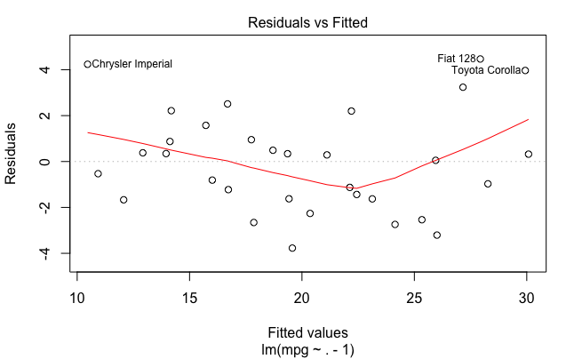

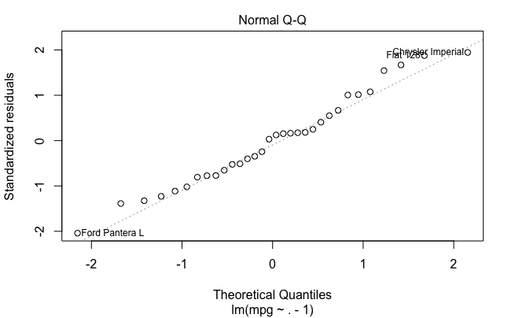

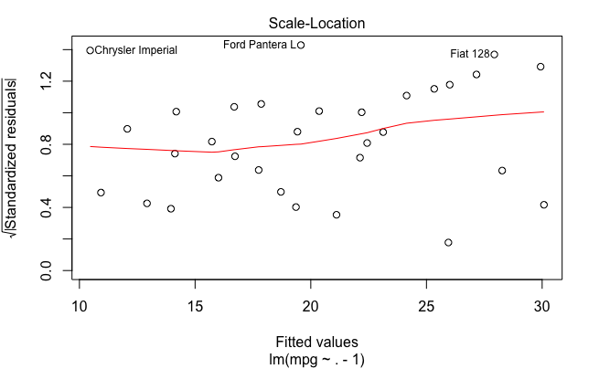

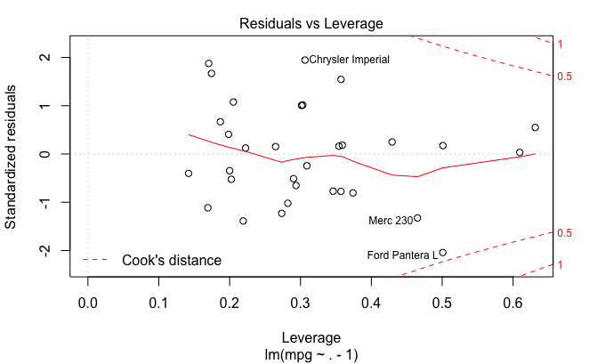

```r
plot(model)
```

# Model interpretation

Looking at the regression coefficients, we see that vehicle weight has the greatest effect on the MPG rating, but the transmission class has the second greatest weight.

This makes intuitive sense, given that heavier things require more gas to push.

This model seems pretty good- the residuals appear more or less randomly distributed.

The R^2 is also much closer to 1 than the previous model, indicating a better fit to the data.

From the residual coefficient for transmission class:

```r
exp(2.83222)
```

```
[1] 16.98312
```

```r
exp(1.97513)
```

```
[1] 7.207557
```